```r
library(faraway)
library(ggplot2)
library(lmtest)
library(MASS)
library(Amelia)
data(sat)
sat
```

```
##                expend ratio salary takers verbal math total
## Alabama         4.405  17.2 31.144      8    491  538  1029
## Alaska          8.963  17.6 47.951     47    445  489   934
## Arizona         4.778  19.3 32.175     27    448  496   944
## Arkansas        4.459  17.1 28.934      6    482  523  1005
## California      4.992  24.0 41.078     45    417  485   902
## Colorado        5.443  18.4 34.571     29    462  518   980
## Connecticut     8.817  14.4 50.045     81    431  477   908
## Delaware        7.030  16.6 39.076     68    429  468   897
## Florida         5.718  19.1 32.588     48    420  469   889
## Georgia         5.193  16.3 32.291     65    406  448   854
## Hawaii          6.078  17.9 38.518     57    407  482   889
## Idaho           4.210  19.1 29.783     15    468  511   979
## Illinois        6.136  17.3 39.431     13    488  560  1048
## Indiana         5.826  17.5 36.785     58    415  467   882
## Iowa            5.483  15.8 31.511      5    516  583  1099
## Kansas          5.817  15.1 34.652      9    503  557  1060
## Kentucky        5.217  17.0 32.257     11    477  522   999
## Louisiana       4.761  16.8 26.461      9    486  535  1021
## Maine           6.428  13.8 31.972     68    427  469   896
## Maryland        7.245  17.0 40.661     64    430  479   909
## Massachusetts   7.287  14.8 40.795     80    430  477   907
## Michigan        6.994  20.1 41.895     11    484  549  1033
## Minnesota       6.000  17.5 35.948      9    506  579  1085
## Mississippi     4.080  17.5 26.818      4    496  540  1036
## Missouri        5.383  15.5 31.189      9    495  550  1045
## Montana         5.692  16.3 28.785     21    473  536  1009
## Nebraska        5.935  14.5 30.922      9    494  556  1050
## Nevada          5.160  18.7 34.836     30    434  483   917
## New Hampshire   5.859  15.6 34.720     70    444  491   935
## New Jersey      9.774  13.8 46.087     70    420  478   898
## New Mexico      4.586  17.2 28.493     11    485  530  1015
## New York        9.623  15.2 47.612     74    419  473   892
## North Carolina  5.077  16.2 30.793     60    411  454   865
## North Dakota    4.775  15.3 26.327      5    515  592  1107
## Ohio            6.162  16.6 36.802     23    460  515   975
## Oklahoma        4.845  15.5 28.172      9    491  536  1027
## Oregon          6.436  19.9 38.555     51    448  499   947
## Pennsylvania    7.109  17.1 44.510     70    419  461   880
## Rhode Island    7.469  14.7 40.729     70    425  463   888
## South Carolina  4.797  16.4 30.279     58    401  443   844
## South Dakota    4.775  14.4 25.994      5    505  563  1068
## Tennessee       4.388  18.6 32.477     12    497  543  1040
## Texas           5.222  15.7 31.223     47    419  474   893
## Utah            3.656  24.3 29.082      4    513  563  1076
## Vermont         6.750  13.8 35.406     68    429  472   901
## Virginia        5.327  14.6 33.987     65    428  468   896
## Washington      5.906  20.2 36.151     48    443  494   937
## West Virginia   6.107  14.8 31.944     17    448  484   932
## Wisconsin       6.930  15.9 37.746      9    501  572  1073
## Wyoming         6.160  14.9 31.285     10    476  525  1001
```

1: Buliding a Model  
a) Run a linear model with response total and predictors expend, ratio, salary, and takers. What is the regression coefficient for ratio

```r
lmod1 <- lm(total ~ expend + ratio + salary + takers, sat)
summary(lmod1)
```

```
##
## Call:
## lm(formula = total ~ expend + ratio + salary + takers, data = sat)
##
## Residuals:
##     Min      1Q  Median      3Q     Max
## -90.531 -20.855  -1.746  15.979  66.571
##
## Coefficients:
##              Estimate Std. Error t value Pr(>|t|)
## (Intercept) 1045.9715    52.8698  19.784  < 2e-16 ***
## expend         4.4626    10.5465   0.423    0.674
## ratio         -3.6242     3.2154  -1.127    0.266
## salary         1.6379     2.3872   0.686    0.496
## takers        -2.9045     0.2313 -12.559 2.61e-16 ***
## ---
## Signif. codes:  0 '***' 0.001 '**' 0.01 '*' 0.05 '.' 0.1 ' ' 1
##
## Residual standard error: 32.7 on 45 degrees of freedom
## Multiple R-squared:  0.8246, Adjusted R-squared:  0.809
## F-statistic: 52.88 on 4 and 45 DF,  p-value: < 2.2e-16
```

ratio -3.6242

2: Checking Normality  
b) Create the usual linear model plots. Looking at the normal qq plot, the normality could be an issue. Why? Run a test to verify whether there really is a problem.

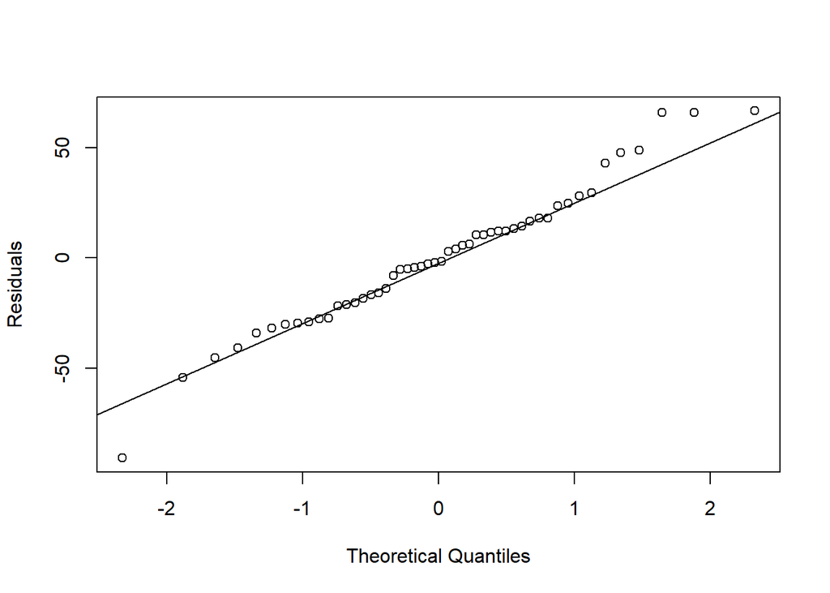

```r
qqnorm(residuals(lmod1),ylab = "Residuals", main ="")
qqline(residuals(lmod1))
```

It seems to have a fatter tails problem  
I am not sure. So, Checking using Shapiro Test

```r
#not Sure
#Checking using Shapiro Test
  shapiro.test(residuals(lmod1))
```

```
##
##  Shapiro-Wilk normality test
##
## data:  residuals(lmod1)
## W = 0.97691, p-value = 0.4304
```

Shapiro test  
H0 : Dist is Normal  
H1 : Dist is Not normal  
P value is High.  
Fail to reject null hypotheses.  
Hence Normal dist.

3. Checking Influentional Observations
3. Looking at the residuals vs. leverage plot, is there a state that we should investigate further?

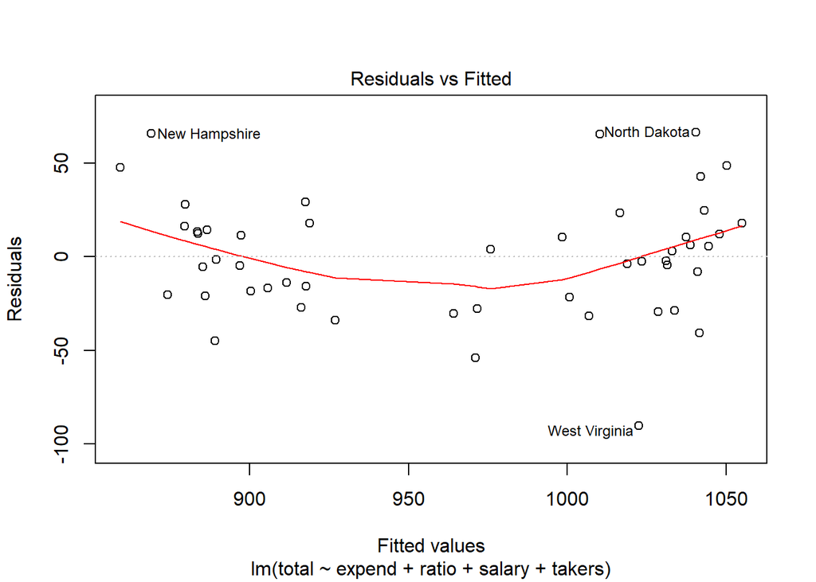

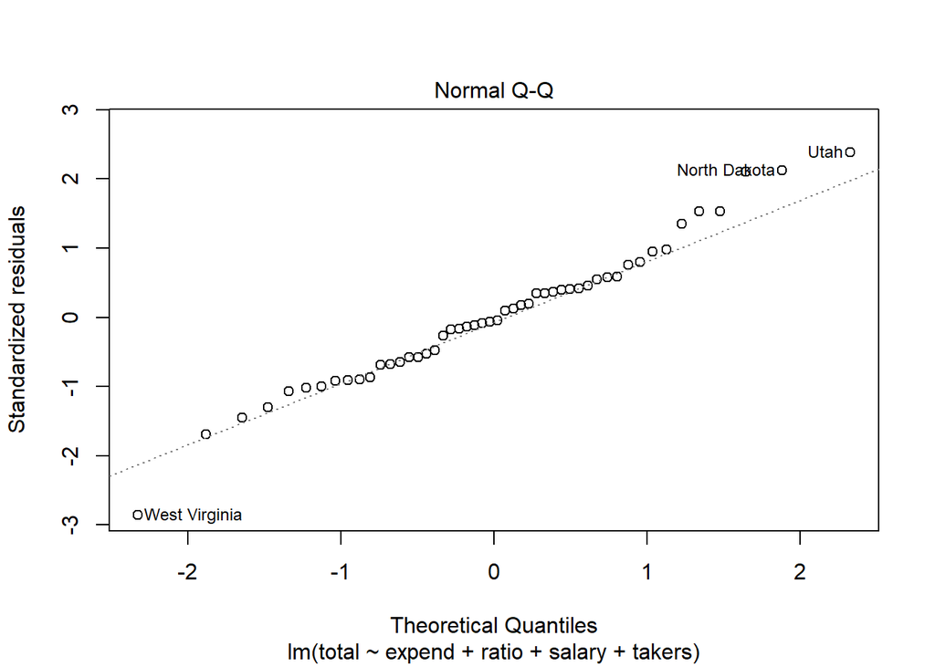

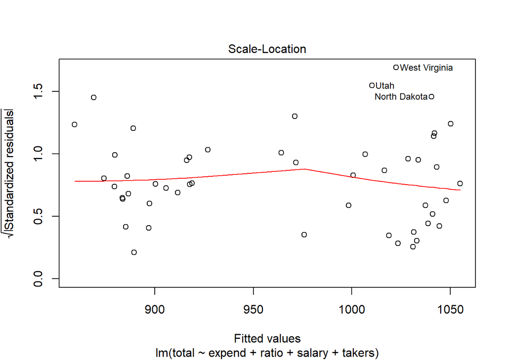

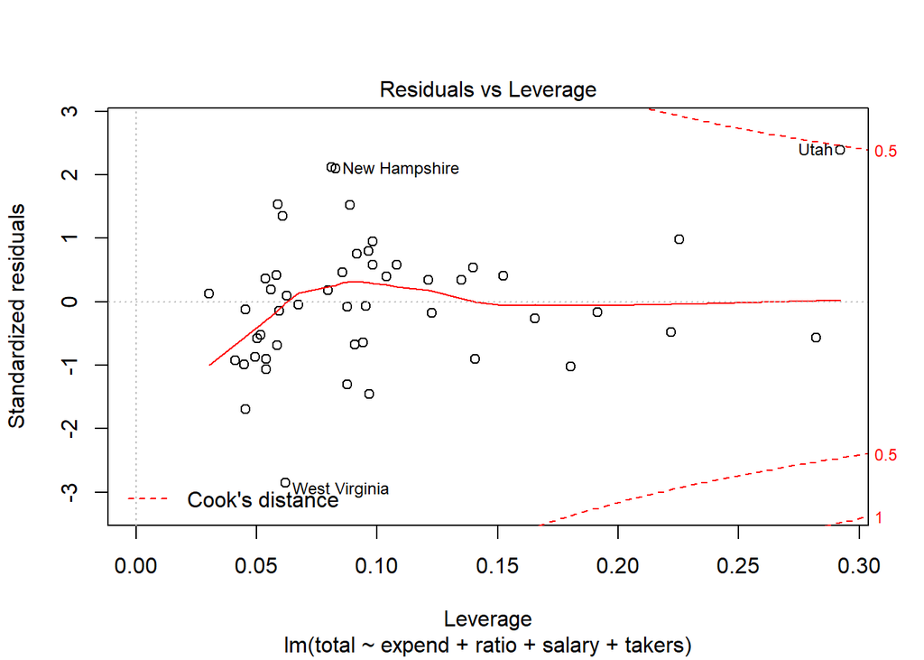

```r
plot(lmod1)
```

None of the points is over 0.5 or 1. Utah is at ~0.5 and could possibly an Influentional point. We need to further Investigate the Suitatiuon  
4) Checking High Leverage Points  
d) Again looking at the residuals vs. leverage plot, approximately how many high leverage points can you identify? Confirm this using code and identify the states with these high leverage points.  
By looking at graph it looks we have 2 high leverage points.  
Lets Verify using code:

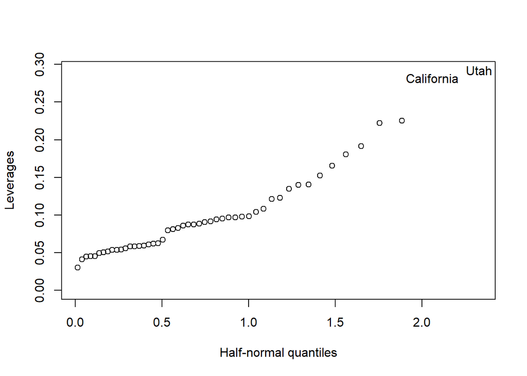

```r
halfnorm(hatvalues(lmod1), labs = row.names(sat), ylab = "Leverages")
```

Utah and California are High leverage points (Observations)  
5) Checking Varience  
e) Create four plots of the residuals versus each of the predictors. Indicate the points for the state you found in c. Does it seem like the state has unusual values for the predictors?

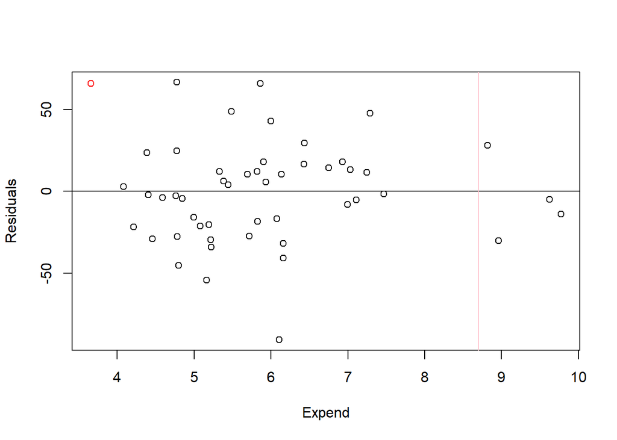

```r
plot(sat$expend, residuals(lmod1), xlab = "Expend", ylab = "Residuals")
abline(h=0)
points(sat["Utah","expend"],residuals(lmod1)["Utah"][[1]], col="red")
abline(v=8.7,col="pink")
```

We can Observe few observations with expend value more then 8.7

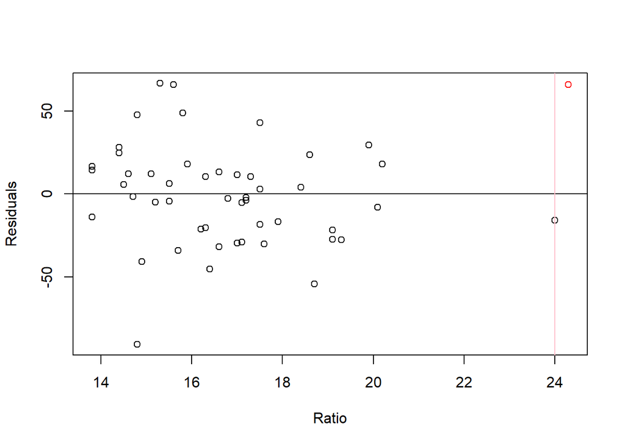

```r
plot(sat$ratio, residuals(lmod1), xlab = "Ratio", ylab = "Residuals")
abline(h=0)
points(sat["Utah","ratio"],residuals(lmod1)["Utah"][[1]], col="red")
abline(v=24,col="pink")
```

We can Observe 2 observations with ratio value more then or equal 24

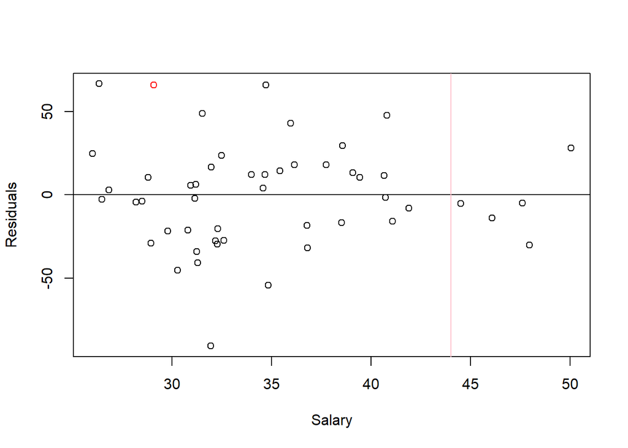

```r
plot(sat$salary, residuals(lmod1), xlab = "Salary", ylab = "Residuals")
abline(h=0)
points(sat["Utah","salary"],residuals(lmod1)["Utah"][[1]], col="red")
abline(v=44,col="pink")
```

We can see Few Observations with salary over 44

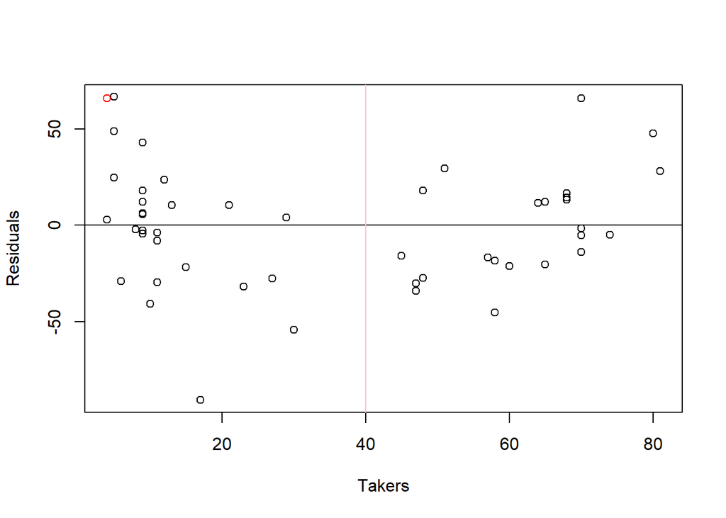

```r
plot(sat$takers, residuals(lmod1), xlab = "Takers", ylab = "Residuals")
abline(h=0)
points(sat["Utah","takers"],residuals(lmod1)["Utah"][[1]], col="red")
abline(v=40,col="pink")
```

we can see the two seperate behivours of Takers below 40 and above 40  
f) Identify any potential issues with any of the plots produced in e).  
i) Residuals vs Expend  
we can we non constant varience.  
ii) Residuals vs Ratio  
Varinece Looks pretty much constant  
iii) Residuals vs Salary  
Non constant variance  
iv) Residuals vs Takers  
Non liearity can be Observed.  
g) Give the four states with the highest residuals (possible outliers) in order, highest last.

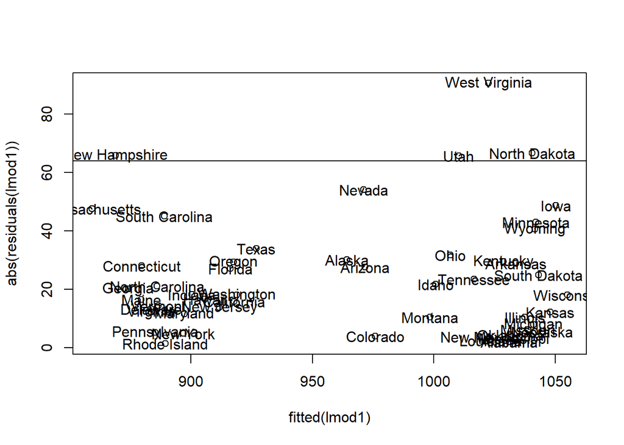

```r
 plot(fitted(lmod1),abs(residuals(lmod1)),)
 text(fitted(lmod1),abs(residuals(lmod1)), labels = row.names(sat))
 abline(h=64)
```

Follwing are the points with highest residuals and could possibly be outliers.  
New Hampshire  
Utah  
North Dakota  
West Virginia  
h) Give the four states with the highest studentized residuals in order, highest last.

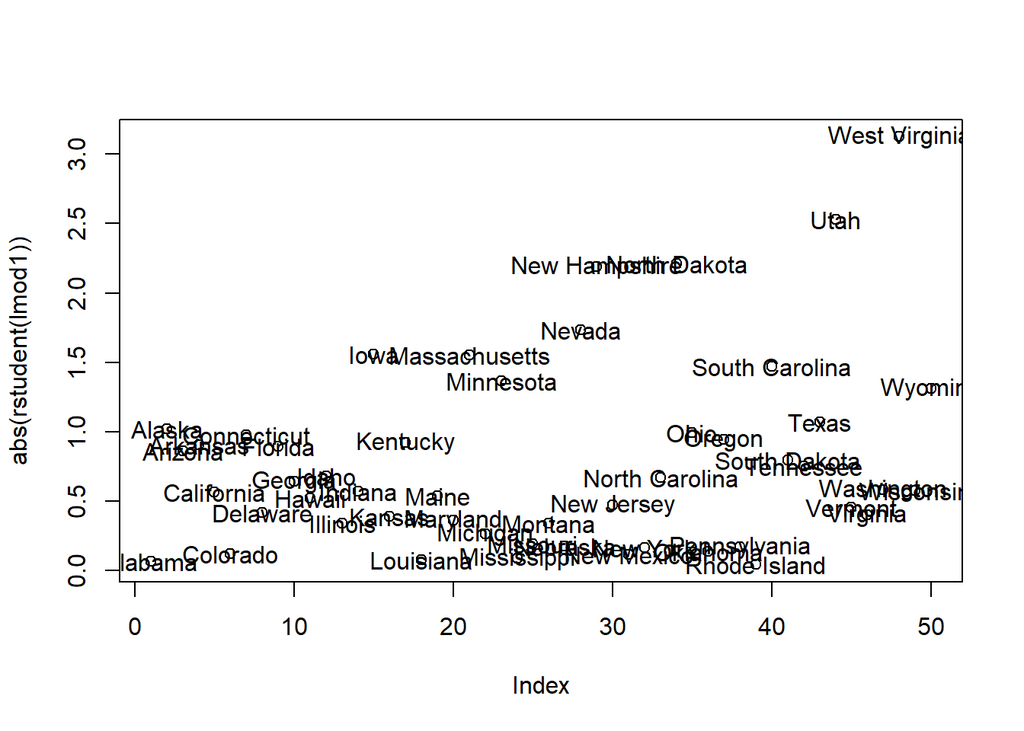

```r
plot(abs(rstudent(lmod1)))
text(abs(rstudent(lmod1)),labels = row.names(sat))
```

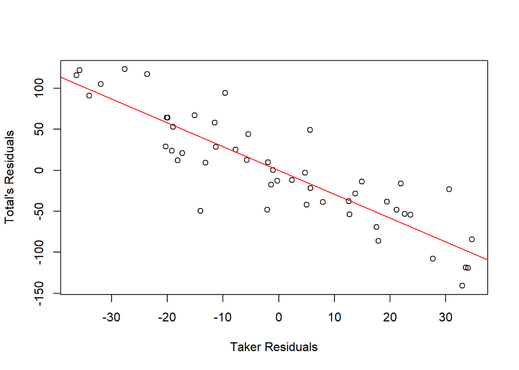

```r
lmod_a <- lm(total ~ expend + ratio + salary , sat)
ra <- residuals(lmod_a)
lmod_b <- lm(takers ~ expend + ratio + salary , sat)
rb <- residuals(lmod_b)
plot(rb,ra, xlab = "Taker Residuals", ylab = "Total's Residuals")
#line
abline(lm(ra~rb),col=2)
```

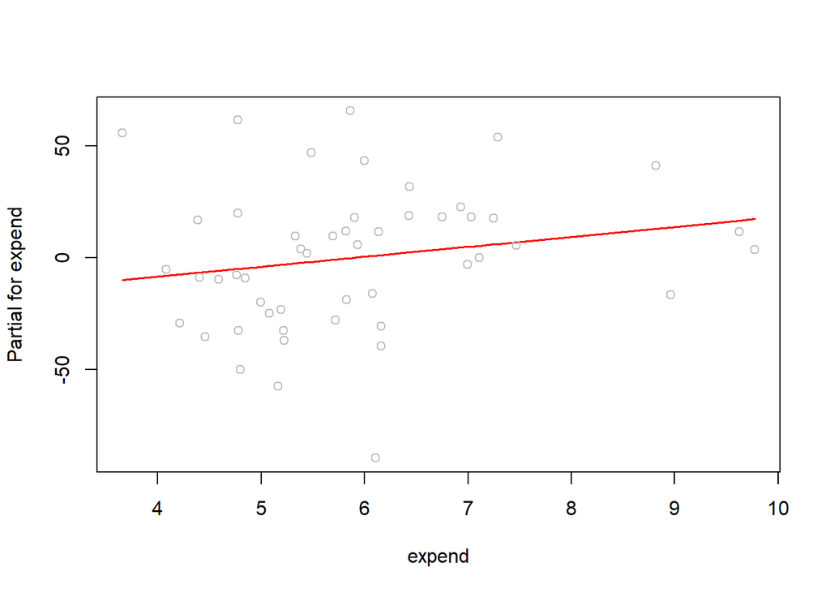

```r
termplot(lmod1, partial.resid = T, terms=1)
```

```r
#Create X without one vector
X1 = model.matrix(lmod1)[,-1]
ev <- eigen(crossprod(X1))
(K=sqrt(ev$val[1]/ev$val)) # 2 values are high
```

```
## [1]   1.000000   3.392475  20.336746 113.750609
```